# German Performance Index

Joe Wood

October 5, 2017

# Question:

What will the daily closing price of Germany’s DAX PERFORMANCE-INDEX (INDEXDB: DAX) be on 31 October 2017?

# Description:

This question will be resolved using the daily closing price of the market of interest reported by Google Finance. Question will be suspended the day before the date of interest and resolved the day after the date of interest.

```r
# Set the working directory to the appropriate HFC folder
setwd('X:\\Personal Development\\Data Science\\HFC\\german_performance_index')
```

```r
library(tseries) # Time series analysis
library(timeSeries) # Linear interpolation method for missing data
library(lubridate) # Date and time manipulations
library(forecast) # For fitting an ARIMA model and doing forecasting
```

I will need to specify the end date for the forecast

```r
end_date <- ymd('20171031')
```

First off I think I’ll import the data…

```r
df <- read.csv('^GDAXI.csv', stringsAsFactors = FALSE)
```

I will also create a full date range to fill in weekends and holidays where the market would be closed, so that I can develop a fully continuous time series with daily intervals

```r
# convert table date to R date object
df$DATE<- mdy(df$Date)

full_range <- data.frame(DATE = seq(min(df$DATE), max(df$DATE), 'days'))

daily_data <- merge(x = full_range, y = df, by = "DATE", all.x = TRUE)
```

I’ll just note that because there are missing observations in the full time series (due to holidays, weekends, or other market closures) I will have to replace them in some fashion. For now, I will use a linear interpolation method until something better occurs to me. This could risk muting some of the true variability of the series, and I could try a few different methods later on and average out the results.

Another option entirely would be to aggregate to a weekly closing, though this is spoiled a bit by the requirement to forecast a daily closing. Because the 31st is a Tuesday, I could start my time series on a Wednesday so the weekly closing would be the same as the daily closing for my time frame. This could take a good bit more cleaning. Also, I would still be spoiled by weeks where there is a holiday on Tuesday

But ah, I digress. To the time series!!

```r
# Interpolate the missing obs
daily_data$Close <- round(interpNA(as.numeric(daily_data$Close), method = "linear"),2)
```

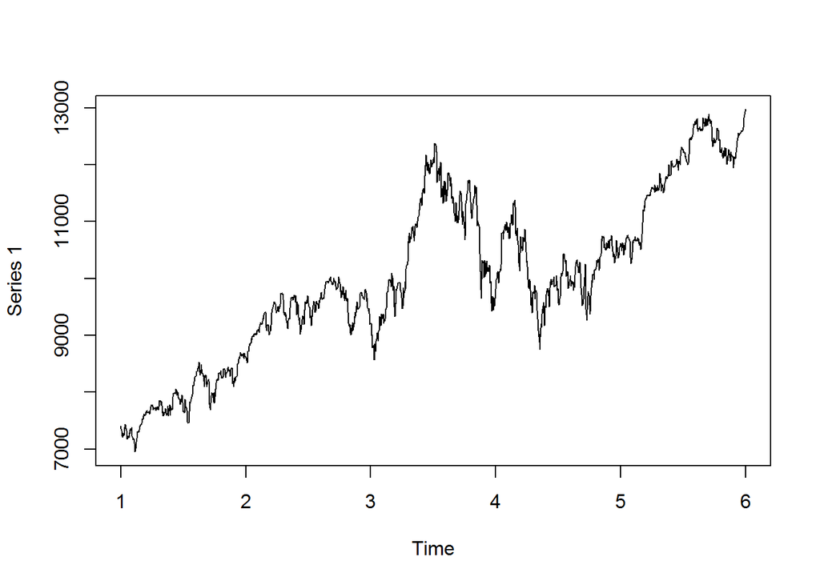

```r
# Create a time series of object with a frequency of 365 to represent that the data is daily
myts <- ts(daily_data$Close, frequency = 365)

plot(myts)
```

Now I will fit an exponential model to the time series using the automatic model specification

```r
fit <- HoltWinters(myts)
```

I will use this exponential model to forecast a range of observations

```r
myfcast <- forecast(fit, h = (end_date - max(daily_data$DATE)), level = c(50,75,80,95) )
myfcast
```

```
##          Point Forecast    Lo 50    Hi 50    Lo 75    Hi 75    Lo 80
## 6.002740       12921.17 12846.56 12995.78 12793.93 13048.42 12779.41
## 6.005479       12891.06 12789.16 12992.96 12717.26 13064.85 12697.44
## 6.008219       12850.78 12727.49 12974.07 12640.50 13061.06 12616.52
## 6.010959       12831.31 12689.82 12972.80 12590.00 13072.61 12562.48
## 6.013699       12942.41 12784.82 13100.00 12673.63 13211.18 12642.98
## 6.016438       13011.73 12839.53 13183.92 12718.04 13305.41 12684.54
## 6.019178       13018.07 12832.40 13203.73 12701.42 13334.71 12665.30
## 6.021918       13012.44 12814.23 13210.65 12674.39 13350.49 12635.83
## 6.024658       13005.92 12795.91 13215.93 12647.74 13364.09 12606.89
## 6.027397       13090.94 12869.76 13312.12 12713.71 13468.17 12670.69
## 6.030137       13133.84 12902.02 13365.65 12738.47 13529.20 12693.38
## 6.032877       13130.25 12888.26 13372.23 12717.54 13542.95 12670.47
## 6.035616       13152.11 12900.37 13403.85 12722.77 13581.46 12673.80
## 6.038356       13167.15 12906.02 13428.28 12721.79 13612.51 12670.99
## 6.041096       13157.77 12887.57 13427.97 12696.94 13618.60 12644.38
## 6.043836       13179.18 12900.21 13458.15 12703.40 13654.97 12649.13
## 6.046575       13246.74 12959.26 13534.21 12756.45 13737.03 12700.53
## 6.049315       13244.38 12948.64 13540.11 12740.00 13748.76 12682.47
## 6.052055       13261.58 12957.81 13565.35 12743.50 13779.66 12684.41
## 6.054795       13272.67 12961.07 13584.27 12741.23 13804.10 12680.62
## 6.057534       13271.44 12952.20 13590.67 12726.98 13815.89 12664.88
## 6.060274       13259.08 12932.39 13585.77 12701.91 13816.26 12638.36
## 6.063014       13287.30 12953.31 13621.28 12717.68 13856.91 12652.72
## 6.065753       13304.28 12963.16 13645.40 12722.50 13886.06 12656.14
## 6.068493       13305.85 12957.74 13653.96 12712.15 13899.55 12644.43
## 6.071233       13334.29 12979.33 13689.25 12728.90 13939.67 12659.85
## 6.073973       13305.03 12943.35 13666.71 12688.18 13921.88 12617.82
##             Hi 80    Lo 95    Hi 95
## 6.002740 13062.93 12704.37 13137.98
## 6.005479 13084.67 12594.95 13187.17
## 6.008219 13085.04 12492.51 13209.05
## 6.010959 13100.14 12420.17 13242.45
## 6.013699 13241.84 12484.47 13400.35
## 6.016438 13338.91 12511.34 13512.11
## 6.019178 13370.83 12478.56 13557.57
## 6.021918 13389.04 12436.47 13588.40
## 6.024658 13404.94 12395.66 13616.18
## 6.027397 13511.19 12448.22 13733.66
## 6.030137 13574.29 12460.21 13807.46
## 6.032877 13590.02 12427.08 13833.41
## 6.035616 13630.43 12420.60 13883.63
## 6.038356 13663.31 12408.34 13925.96
## 6.041096 13671.16 12372.61 13942.93
## 6.043836 13709.24 12368.54 13989.83
## 6.046575 13792.95 12411.38 14082.09
## 6.049315 13806.28 12385.02 14103.74
## 6.052055 13838.75 12378.87 14144.29
## 6.054795 13864.71 12367.21 14178.12
## 6.057534 13877.99 12343.79 14199.08
## 6.060274 13879.81 12309.76 14208.40
## 6.063014 13921.88 12316.79 14257.80
## 6.065753 13952.41 12313.04 14295.52
## 6.068493 13967.27 12294.30 14317.40
## 6.071233 14008.72 12302.83 14365.75
## 6.073973 13992.24 12254.04 14356.02
```

A plot of the forecast

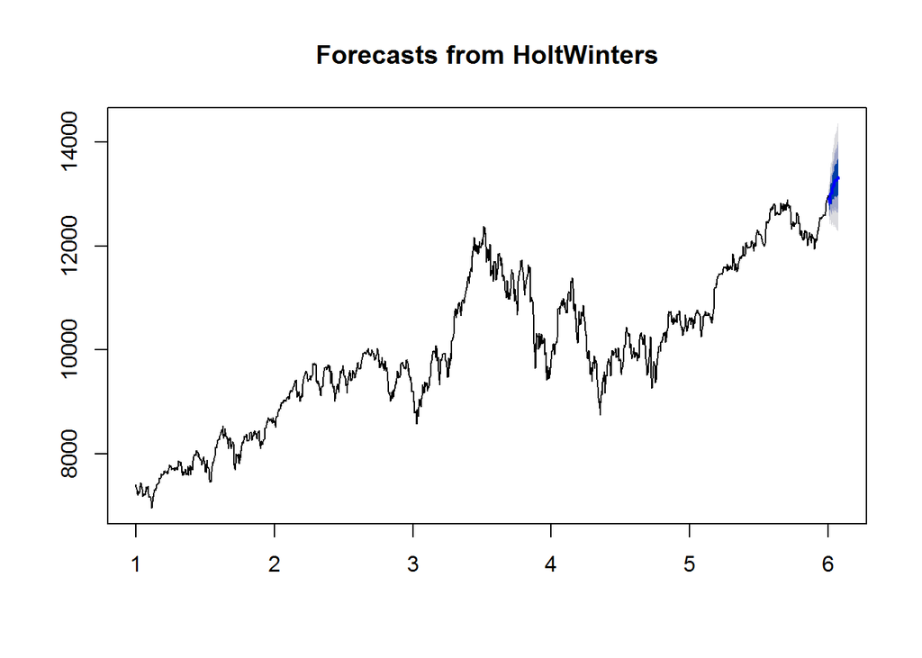

```r
plot(myfcast)
```

The forecasted value for the end of the period

```r
paste("The point estimate is", round(myfcast$mean[(end_date - max(daily_data$DATE))],2))
```

```
## [1] "The point estimate is 13305.03"
```

```r
paste("There is a 50% chance that the value will be between",round(myfcast$lower[(end_date - max(daily_data$DATE)),1],2), "and", round(myfcast$upper[(end_date - max(daily_data$DATE)),1],2))
```

```
## [1] "There is a 50% chance that the value will be between 12943.35 and 13666.71"
```

```r
paste("There is a 75% chance that the value will be between",round(myfcast$lower[(end_date - max(daily_data$DATE)),2],2), "and", round(myfcast$upper[(end_date - max(daily_data$DATE)),2],2))
```

```
## [1] "There is a 75% chance that the value will be between 12688.18 and 13921.88"
```

```r
paste("There is a 80% chance that the value will be between",round(myfcast$lower[(end_date - max(daily_data$DATE)),3],2), "and", round(myfcast$upper[(end_date - max(daily_data$DATE)),3],2))
```

```
## [1] "There is a 80% chance that the value will be between 12617.82 and 13992.24"
```

```r
paste("There is a 95% chance that the value will be between",round(myfcast$lower[(end_date - max(daily_data$DATE)),4],2), "and", round(myfcast$upper[(end_date - max(daily_data$DATE)),4],2))
```

```
## [1] "There is a 95% chance that the value will be between 12254.04 and 14356.02"
```

Based on the mean and available intervals, we can calculate a standard deviation.

This can be used to calculate the appropriate mount for the buckets on GJopen

```r
mean <- as.numeric(myfcast$mean[(end_date - max(daily_data$DATE))])

# 1.15 is the z-Score for a 75% confidence interval
stddev <- as.numeric((myfcast$lower[(end_date - max(daily_data$DATE)),2] - mean)/ (-1.15))
```

Interval 1 < 11897.71

```r
z1 <- (11897.71 - mean) / stddev
z1
```

```
## [1] -2.623673
```

```r
prob1 <- round(pnorm(z1)*100,0)
prob1
```

```
## [1] 0
```

Interval 2 11897.71 <= x <= 12213.98

```r
z2l <- (11897.71 - mean) / stddev
z2l
```

```
## [1] -2.623673
```

```r
z2u <- (12213.98 - mean) / stddev
z2u
```

```
## [1] -2.034049
```

```r
prob2 <- round(pnorm(z2u)*100,0) - round(pnorm(z2l)*100,0)
prob2
```

```
## [1] 2
```

Interval 3 x > 12213.98

```r
z3 <- (12213.98 - mean) / stddev
z3
```

```
## [1] -2.034049
```

```r
prob3 <- 100 - round(pnorm(z3)*100,0)
prob3
```

```
## [1] 98
```

Sanity check

```r
prob1 + prob2 + prob3
```

```
## [1] 100
```

## Simple forecast to today’s date

```r
paste("Today, the forecast would have predicted a rate of", round(myfcast$mean[(today() - max(daily_data$DATE))],2))
```

```
## [1] "Today, the forecast would have predicted a rate of 12921.17"
```